# Программирование в командном процессоре ОС UNIX. Ветвления и циклы

Лабораторная работа No 11

Козлова Нонна

Российский университет дружбы народов, Москва, Россия

НБИбд-04-22

## Цели и задачи

Изучить основы программирования в оболочке ОС UNIX. Научится писать более сложные командные файлы с использованием логических управляющих конструкций и циклов.

## Содержание исследования

1. Используя команды getopts grep, написала командный файл, который анализирует командную строку с ключами: – -iinputfile — прочитать данные из указанного файла; – -ooutputfile — вывести данные в указанный файл; – -pшаблон — указать шаблон для поиска; – -C — различать большие и малые буквы; – -n — выдавать номера строк. а затем ищет в указанном файле нужные строки, определяемые ключом -p.(рис. @fig:001).

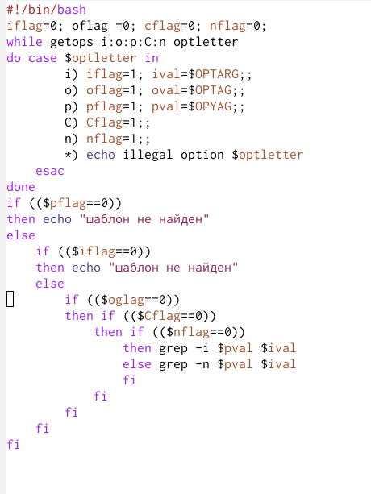

Код

2. Написала на языке Си программу, которая вводит число и определяет, является ли оно больше нуля, меньше нуля или равно нулю.(рис. @fig:002), (рис. @fig:003).

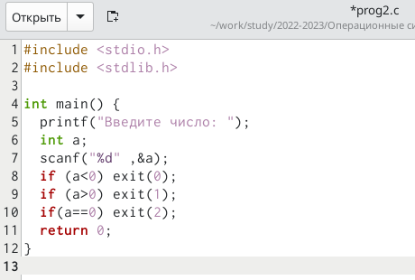

Код

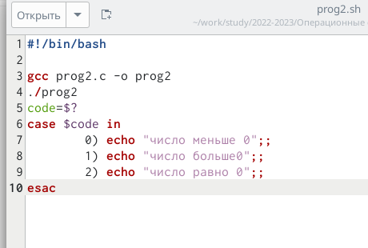

Код

3. Проверяю работу программы (рис. @fig:004).

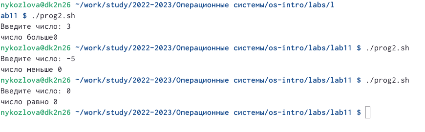

Работает

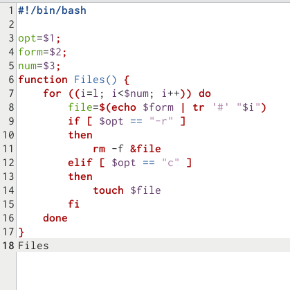

Код

5. Проверяю работу программы (рис. @fig:006).

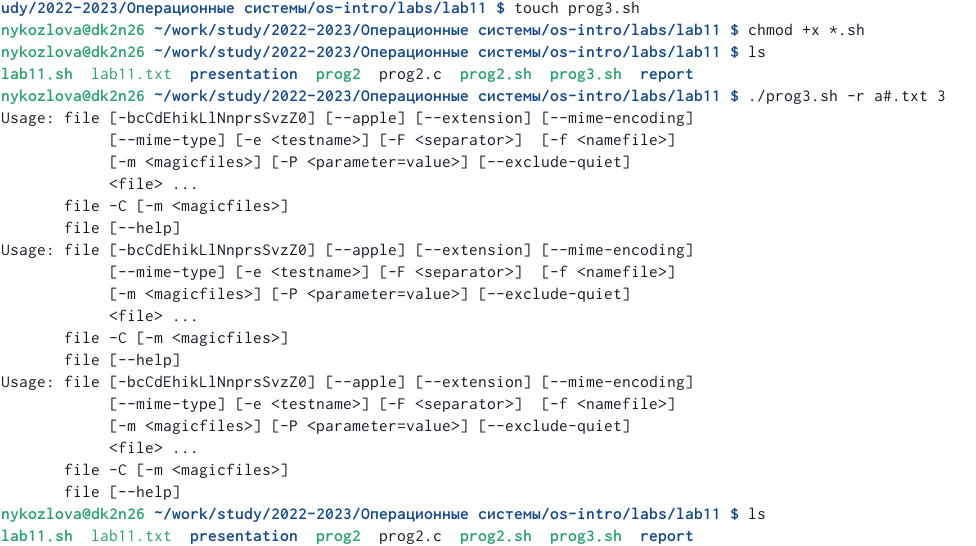

6. Пишу командный файл, который с помощью команды tar запаковывает в архив все файлы в указанной директории. Модифицирую его так, чтобы запаковывались только те файлы, которые были изменены менее недели тому назад (рис. @fig:007).

[figure not shown]

Использую команду find

## Вывод

В хаде лабораторной работы, я изучила основы программирования в оболочке ОС UNIX, нааучилась писать более сложные командные файлы с использованием логических управляющих конструкций и циклов.